# Data types and classes

Lecture 8

2024-05-28

## Announcements

- Exam 1 in class next week on Monday – cheat sheet (1 page, both sides, hand-written or typed, must be prepared by you)
- Exam 1 take home starts after class on **Monday**, due at 11:59 PM on **Thursday** (open resources, internet, etc., closed to other humans) - I nor the TA will be available to answer questions!!
- Next class: Exam 1 review – come with questions!

## Study tips for the exam

- Go over lecture materials and application exercises
- Review labs and feedback you’ve received so far
- In particular, please go over Lab 2 and make sure you understand every question.
- Do the exercises at the end of readings from both books
- Do the exam review
- Please come to class and office hours with questions! There are no stupid questions!

# Questions from last semester

## **Pivoting data**

Suppose we have the following patient data:

```r
patients
```

```
# A tibble: 3 × 4
  patient_id pulse_1 pulse_2 pulse_3
  <chr>        <dbl>   <dbl>   <dbl>
1 XYZ             70      85      73
2 ABC             90      95     102
3 DEF            100      80      70
```

And we want to know:

- Average pulse rate for each patient.
- Trends in pulse rates across measurements.

## **Pivoting data**

Suppose we have the following patient data:

```r
patients
```

```
# A tibble: 3 × 4
  patient_id pulse_1 pulse_2 pulse_3
  <chr>        <dbl>   <dbl>   <dbl>
1 XYZ             70      85      73
2 ABC             90      95     102
3 DEF            100      80      70
```

And we want to know:

- Average pulse rate for each patient.
- Trends in pulse rates across measurements.

These require a *longer* format of the data where all pulse rates are in a single column and another column identifies the measurement number.

## Pivoting data

```r
patients_longer <- patients |>
  pivot_longer(
    cols = !patient_id,
    names_to = "measurement",
    values_to = "pulse_rate"
  )
```

## Summarizing pivoted data

```r
patients_longer |>
  group_by(patient_id) |>
  summarize(mean_pulse = mean(pulse_rate))
```

```
# A tibble: 3 × 2
  patient_id mean_pulse
  <chr>           <dbl>
1 ABC              95.7
2 DEF              83.3
3 XYZ              76
```

## Visualizing pivoted data

```r
ggplot(
  patients_longer,
  aes(x = measurement, y = pulse_rate, group = patient_id, color = patient_id)
  ) +
  geom_line()
```

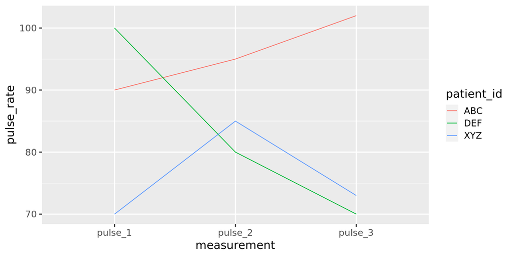

# Types and classes

## Types and classes

- Type is how an object is stored in memory, e.g.,
  - `double`: a real number stored in double-precision floatint point format.
  - `integer`: an integer (positive or negative)
- Class is metadata about the object that can determine how common functions operate on that object, e.g.,
  - `factor`

## Types of vectors

You’ll commonly encounter:

- `logical`
- `integer`
- `double`
- `character`

You’ll less commonly encounter:

- `list`
- `NULL`
- `complex`
- `raw`

## Types of functions

Yes, functions have types too, but you don’t need to worry about the differences in the context of doing data science.

```r
typeof(mean) # regular function
```

```
[1] "closure"
```

```r
typeof(`$`) # internal function
```

```
[1] "special"
```

```r
typeof(sum) # primitive function
```

```
[1] "builtin"
```

## Factors

A `factor` is a vector that can contain only predefined values. It is used to store categorical data.

```r
x <- factor(c("a", "b", "b", "a"))
x
```

```
[1] a b b a
Levels: a b
```

```r
typeof(x)
```

```
[1] "integer"
```

```r
attributes(x)
```

```
$levels
[1] "a" "b"

$class
[1] "factor"
```

[figure not shown]

## Other classes

Just a couple of examples…

Date:

```r
today <- Sys.Date()
today
```

```
[1] "2024-05-28"
```

```r
typeof(today)
```

```
[1] "double"
```

```r
attributes(today)
```

```
$class
[1] "Date"
```

Date-time:

```r
now <- as.POSIXct("2024-02-08 11:45", tz = "EST")
now
```

```
[1] "2024-02-08 11:45:00 EST"
```

```r
typeof(now)
```

```
[1] "double"
```

```r
attributes(now)
```

```
$class
[1] "POSIXct" "POSIXt"

$tzone
[1] "EST"
```

# Application exercise

## `ae-07-population-types`

- Go to the project navigator in RStudio (top right corner of your RStudio window) and open the project called `ae`.
- If there are any uncommitted files, commit them, and then click **Pull**.
- Open the file called `ae-07-population-types.qmd` and render it.

[🔗 sta199-summer24.github.io](https://sta199-s24.github.io/) · [❓ Ask on Ed](https://edstem.org/us/courses/59071/discussion/)